# Tugas MPDW P2

Zafira Ilma Fitri

2023-09-04

#### Memanggil library package yang dibutuhkan

```r
library("forecast")
```

```r
library("graphics")
library("TTR")
library("TSA")
```

#### Mengimpor Data

```r
library(readxl)
data <- read_excel("C:/Users/Zifferentpg/OneDrive/Documents/mpdw.xlsx")
View(data)
str(data)
```

```
## tibble [120 × 2] (S3: tbl_df/tbl/data.frame)
##  $ date : num [1:120] 1 2 3 4 5 6 7 8 9 10 ...
##  $ value: num [1:120] 308833 309027 309212 309191 309369 ...
```

```r
dim(data)
```

```
## [1] 120   2
```

#### Mengubah data menjadi objek time series

```r
data.ts <- ts(data$value)
summary(data.ts)
```

```
##    Min. 1st Qu.  Median    Mean 3rd Qu.    Max.
##  308833  314163  319837  319697  325231  330309
```

#### Membuat plot deret waktu

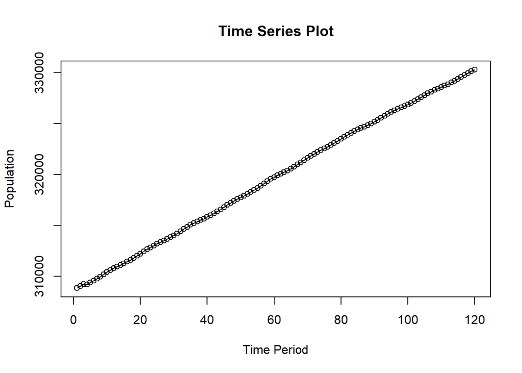

```r
ts.plot(data.ts, xlab="Time Period", ylab="Population",
        main = "Time Series Plot")
points(data.ts)
```

#### Menyimpan Plot

```r
#menyimpan plot
#dev.copy(png, "eksplorasi.png")
#dev.off()
```

Pada grafik yang terlihat, diketahui pola data yang digunakan cenderung berpola tren. Pada data dengan pola tren, maka metode pemulusan yang cocok digunakan adalah rata-rata bergerak ganda (double moving average) dan pemulusan exponensial ganda (double exponential smoothing)

#### Pembagian Data

Pembagian data latih dan data uji dilakukan dengan perbandingan 80% data latih dan 20% data uji.

```r
#membagi data latih dan data uji
training_ma <- data[1:96,]
testing_ma <- data[97:120,]
train_ma.ts <- ts(training_ma$value)
test_ma.ts <- ts(testing_ma$value)
```

### Eksplorasi Data

Eksplorasi data dilakukan pada data training dan data test menggunakan plot data deret waktu

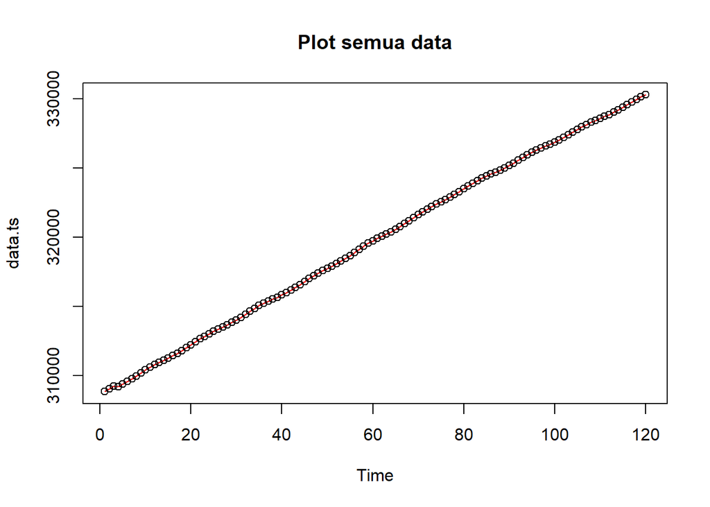

```r
#eksplorasi keseluruhan data
plot(data.ts, col="red",main="Plot semua data")
points(data.ts)
```

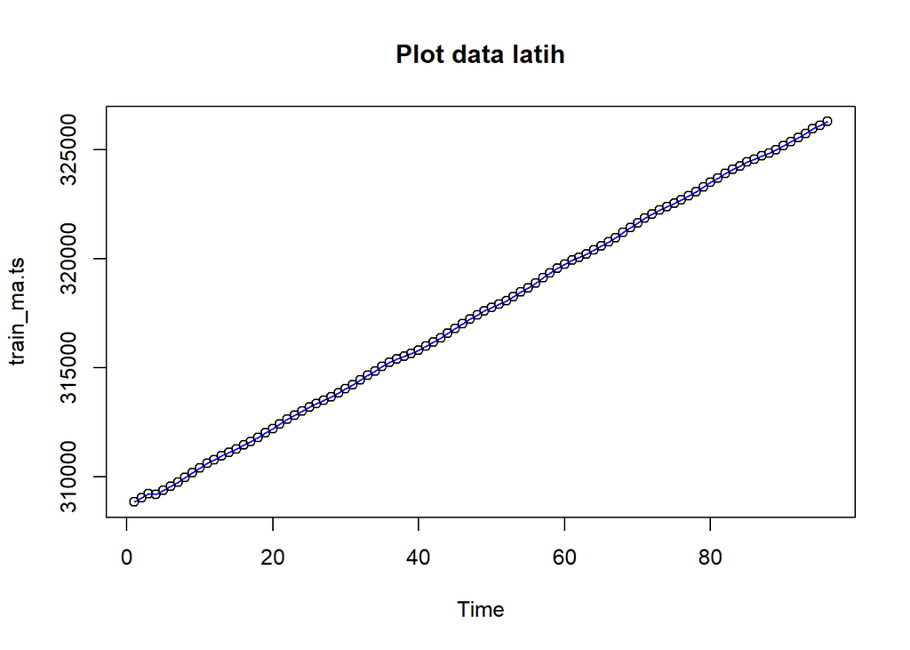

```r
#eksplorasi data latih
plot(train_ma.ts, col="blue",main="Plot data latih")
points(train_ma.ts)
```

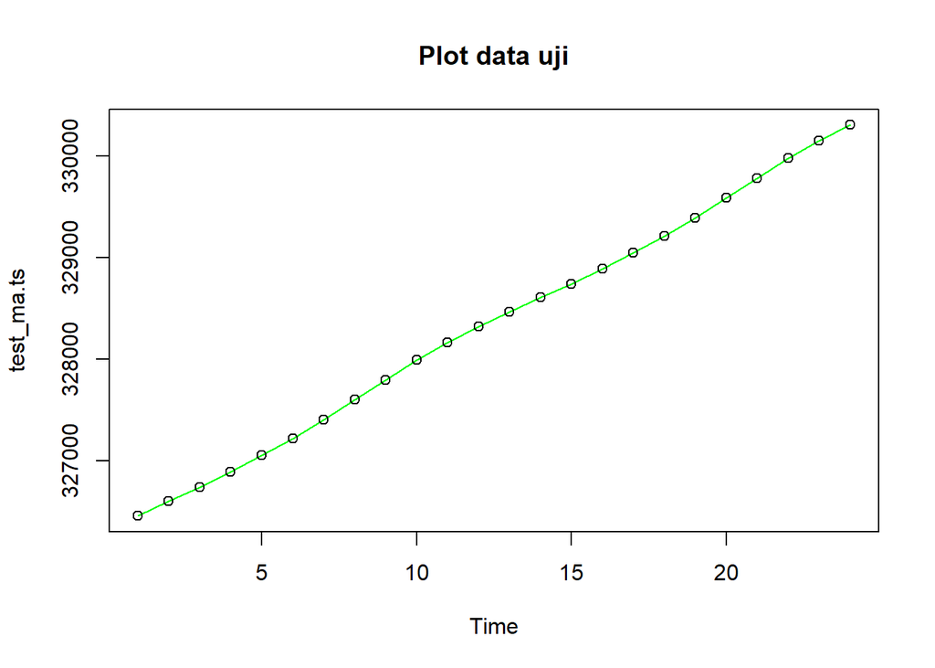

```r
#eksplorasi data uji
plot(test_ma.ts, col="green",main="Plot data uji")
points(test_ma.ts)
```

#### Melakukan eksplorasi data dengan menggunakan package ggplot

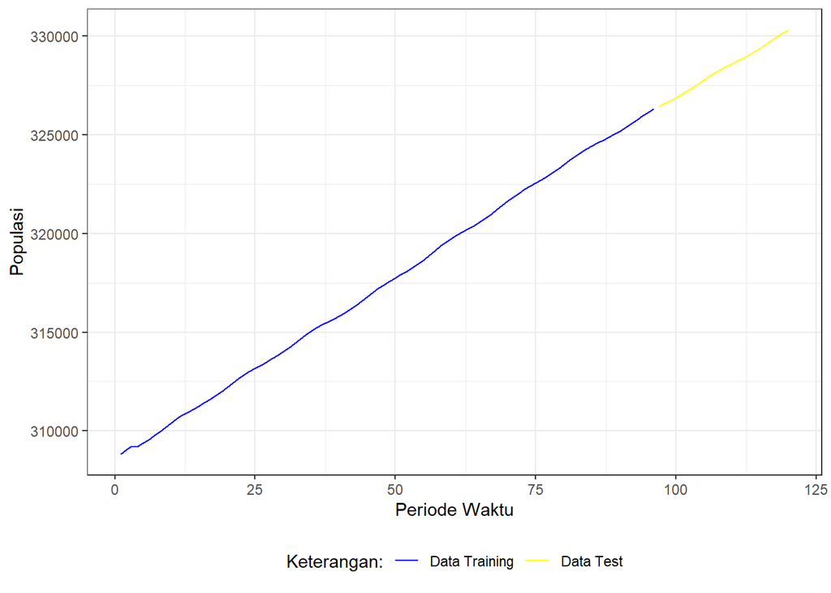

```r
#Eksplorasi dengan ggplot
library(ggplot2)
ggplot() +
  geom_line(data = training_ma, aes(x = date, y = value, col = "Data Training")) +
  geom_line(data = testing_ma, aes(x = date, y = value, col = "Data Test")) +
  labs(x = "Periode Waktu", y = "Populasi", color = "Legend") +
  scale_colour_manual(name="Keterangan:", breaks = c("Data Training", "Data Test"),
                      values = c("blue", "yellow")) +
  theme_bw() + theme(legend.position = "bottom",
                     plot.caption = element_text(hjust=0.5, size=12))
```

## Single Moving Average (SMA) & Double Moving Average (DMA)

### Single Moving Average (SMA)

Pengujian menggunakan metode SMA dilakukan untuk melihat ketidakcocokan penggunaan metode ini pada data yang berpola tren. Karena, metode SMA cocok digunakan untuk data yang stasioner atau konstan.

```r
data.sma<-SMA(train_ma.ts, n=2)
data.sma
```

```
## Time Series:
## Start = 1
## End = 96
## Frequency = 1
##  [1]       NA 308930.0 309119.5 309201.5 309280.0 309459.0 309647.5 309852.0
##  [9] 310067.0 310287.5 310497.5 310689.0 310871.5 311037.0 311189.0 311350.5
## [17] 311521.5 311699.0 311894.0 312101.0 312317.0 312536.5 312736.5 312919.0
## [25] 313096.0 313261.0 313419.0 313583.0 313749.0 313924.5 314114.5 314316.5
## [33] 314534.5 314750.5 314954.0 315143.5 315311.0 315454.5 315591.0 315740.0
## [41] 315901.0 316077.5 316265.0 316469.5 316693.0 316914.0 317125.0 317319.5
## [49] 317502.5 317674.0 317835.5 318003.0 318179.0 318366.5 318563.0 318778.0
## [57] 319009.5 319239.0 319458.5 319655.0 319837.0 320001.0 320152.0 320316.0
## [65] 320493.0 320678.5 320875.5 321090.0 321314.5 321540.0 321754.5 321949.5
## [73] 322138.0 322315.5 322474.5 322636.0 322810.0 322993.5 323189.5 323396.0
## [81] 323605.0 323814.0 324012.5 324190.5 324356.5 324509.5 324647.0 324787.5
## [89] 324940.5 325102.5 325276.5 325467.5 325667.0 325866.0 326054.0 326221.5
```

Data pemulusan pada periode ke-t selanjutnya digunakan sebagai nilai peramalan pada periode ke t+1 sehingga hasil peramalan 1 periode kedepan adalah sebagai berikut.

```r
data.ramal<-c(NA,data.sma)
data.ramal #forecast 1 periode ke depan
```

```
##  [1]       NA       NA 308930.0 309119.5 309201.5 309280.0 309459.0 309647.5
##  [9] 309852.0 310067.0 310287.5 310497.5 310689.0 310871.5 311037.0 311189.0
## [17] 311350.5 311521.5 311699.0 311894.0 312101.0 312317.0 312536.5 312736.5
## [25] 312919.0 313096.0 313261.0 313419.0 313583.0 313749.0 313924.5 314114.5
## [33] 314316.5 314534.5 314750.5 314954.0 315143.5 315311.0 315454.5 315591.0
## [41] 315740.0 315901.0 316077.5 316265.0 316469.5 316693.0 316914.0 317125.0
## [49] 317319.5 317502.5 317674.0 317835.5 318003.0 318179.0 318366.5 318563.0
## [57] 318778.0 319009.5 319239.0 319458.5 319655.0 319837.0 320001.0 320152.0
## [65] 320316.0 320493.0 320678.5 320875.5 321090.0 321314.5 321540.0 321754.5
## [73] 321949.5 322138.0 322315.5 322474.5 322636.0 322810.0 322993.5 323189.5
## [81] 323396.0 323605.0 323814.0 324012.5 324190.5 324356.5 324509.5 324647.0
## [89] 324787.5 324940.5 325102.5 325276.5 325467.5 325667.0 325866.0 326054.0
## [97] 326221.5
```

Selanjutnya akan dilakukan peramalan sejumlah data uji yaitu 24 periode. Pada metode SMA, hasil peramalan 24 periode ke depan akan bernilai sama dengan hasil peramalan 1 periode kedepan. Dalam hal ini akan dilakukan penggabungan data aktual train, data hasil pemulusan dan data hasil ramalan 24 periode kedepan.

```r
data.gab<-cbind(aktual=c(train_ma.ts,rep(NA,24)),pemulusan=c(data.sma,rep(NA,24)),ramalan=c(data.ramal,rep(data.ramal[length(data.ramal)],23)))
data.gab #forecast 24 periode ke depan
```

```
##        aktual pemulusan  ramalan
##   [1,] 308833        NA       NA
##   [2,] 309027  308930.0       NA
##   [3,] 309212  309119.5 308930.0
##   [4,] 309191  309201.5 309119.5
##   [5,] 309369  309280.0 309201.5
##   [6,] 309549  309459.0 309280.0
##   [7,] 309746  309647.5 309459.0
##   [8,] 309958  309852.0 309647.5
##   [9,] 310176  310067.0 309852.0
##  [10,] 310399  310287.5 310067.0
##  [11,] 310596  310497.5 310287.5
##  [12,] 310782  310689.0 310497.5
##  [13,] 310961  310871.5 310689.0
##  [14,] 311113  311037.0 310871.5
```

[output cut: 106 more lines]

Berikut merupakan plot data deret waktu dari peramalan.

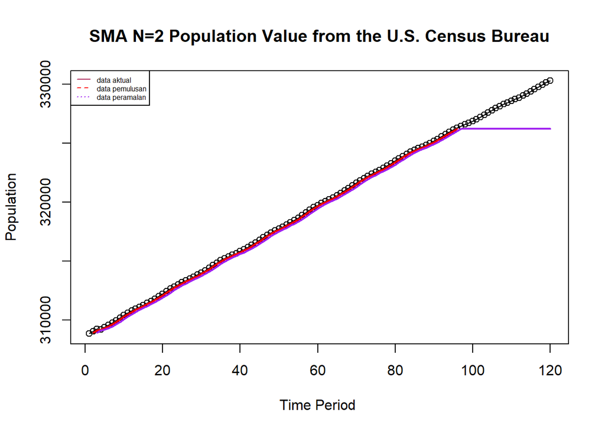

```r
ts.plot(data.ts, xlab="Time Period ", ylab="Population", main= "SMA N=2 Population Value from the U.S. Census Bureau")
points(data.ts)
lines(data.gab[,2],col="red",lwd=2)
lines(data.gab[,3],col="purple",lwd=2)
legend("topleft",c("data aktual","data pemulusan","data peramalan"), lty=1:3, col=c("maroon","red","purple"), cex=0.5)
```

Selanjutnya perhitungan akurasi dilakukan dengan ukuran akurasi MSE dan MAPE. Perhitungan akurasi dilakukan pada data train dan data test.

```r
#Menghitung nilai keakuratan data latih
error_train.sma = train_ma.ts-data.ramal[1:length(train_ma.ts)]
SSE_train.sma = sum(error_train.sma[5:length(train_ma.ts)]^2)
MSE_train.sma = mean(error_train.sma[5:length(train_ma.ts)]^2)
MAPE_train.sma = mean(abs((error_train.sma[5:length(train_ma.ts)]/train_ma.ts[5:length(train_ma.ts)])*100))

akurasi_train.sma <- matrix(c(SSE_train.sma, MSE_train.sma, MAPE_train.sma))
row.names(akurasi_train.sma)<- c("SSE", "MSE", "MAPE")
colnames(akurasi_train.sma) <- c("Akurasi m = 4")
akurasi_train.sma
```

```
##      Akurasi m = 4
## SSE   7.235609e+06
## MSE   7.864792e+04
## MAPE  8.747184e-02
```

```r
#Menghitung nilai keakuratan data test
error_test.sma = test_ma.ts-data.gab[97:120,3]
SSE_test.sma = sum(error_test.sma^2)
MSE_test.sma = mean(error_test.sma^2)
MAPE_test.sma = mean(abs((error_test.sma/test_ma.ts*100)))

akurasi_test.sma <- matrix(c(SSE_test.sma, MSE_test.sma, MAPE_test.sma))
row.names(akurasi_test.sma)<- c("SSE", "MSE", "MAPE")
colnames(akurasi_test.sma) <- c("Akurasi m = 4")
akurasi_test.sma
```

```
##      Akurasi m = 4
## SSE   1.412836e+08
## MSE   5.886816e+06
## MAPE  6.471191e-01
```

### Double Moving Average (DMA)

```r
dma <- SMA(data.sma, n = 2)
At <- 2*data.sma - dma
Bt <- (data.sma - dma)
data.dma<- At+Bt
data.ramal2<- c(NA, data.dma)

t = 1:24
f = c()

for (i in t) {
  f[i] = At[length(At)] + Bt[length(Bt)]*(i)
}

data.gab2 <- cbind(aktual = c(train_ma.ts,rep(NA,24)), pemulusan1 = c(data.sma,rep(NA,24)),pemulusan2 = c(data.dma, rep(NA,24)),At = c(At, rep(NA,24)), Bt = c(Bt,rep(NA,24)),ramalan = c(data.ramal2, f[-1]))
data.gab2
```

```
##        aktual pemulusan1 pemulusan2       At     Bt  ramalan
##   [1,] 308833         NA         NA       NA     NA       NA
##   [2,] 309027   308930.0         NA       NA     NA       NA
##   [3,] 309212   309119.5   309309.0 309214.2  94.75       NA
##   [4,] 309191   309201.5   309283.5 309242.5  41.00 309309.0
##   [5,] 309369   309280.0   309358.5 309319.2  39.25 309283.5
##   [6,] 309549   309459.0   309638.0 309548.5  89.50 309358.5
##   [7,] 309746   309647.5   309836.0 309741.8  94.25 309638.0
##   [8,] 309958   309852.0   310056.5 309954.2 102.25 309836.0
##   [9,] 310176   310067.0   310282.0 310174.5 107.50 310056.5
##  [10,] 310399   310287.5   310508.0 310397.8 110.25 310282.0
##  [11,] 310596   310497.5   310707.5 310602.5 105.00 310508.0
##  [12,] 310782   310689.0   310880.5 310784.8  95.75 310707.5
##  [13,] 310961   310871.5   311054.0 310962.8  91.25 310880.5
##  [14,] 311113   311037.0   311202.5 311119.8  82.75 311054.0
```

[output cut: 106 more lines]

Hasil pemulusan menggunakan metode DMA divisualisasikan sebagai berikut

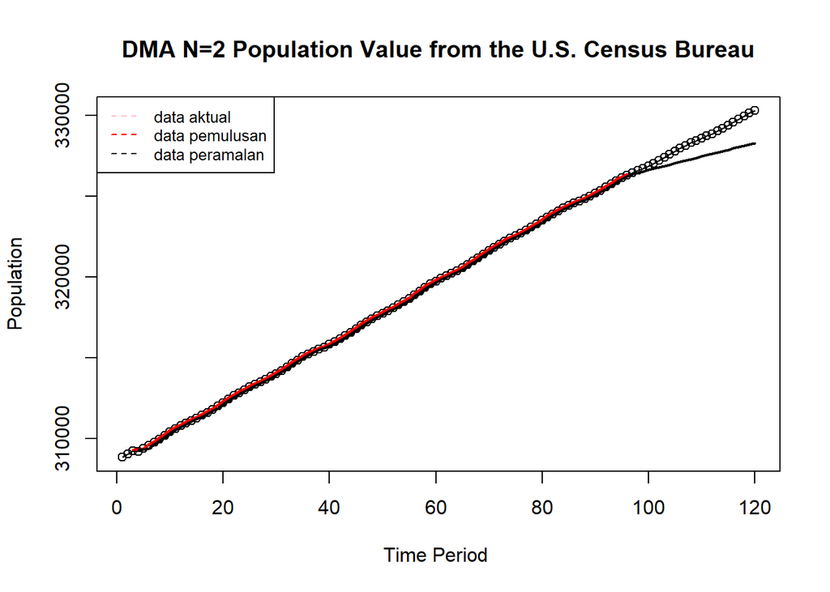

```r
ts.plot(data.ts, xlab="Time Period ", ylab="Population", main= "DMA N=2 Population Value from the U.S. Census Bureau")
points(data.ts)
lines(data.gab2[,3],col="red",lwd=2)
lines(data.gab2[,6],col="black",lwd=2)
legend("topleft",c("data aktual","data pemulusan","data peramalan"), lty=8, col=c("pink","red","black"), cex=0.8)
```

Perhitungan akurasi dilakukan pada data training dan data test dengan MENGGUNAKAN ukuran akurasi SSE, MSE dan MAPE.

```r
#Menghitung nilai keakuratan data train
error_train.dma = train_ma.ts-data.ramal2[1:length(train_ma.ts)]
SSE_train.dma = sum(error_train.dma[8:length(train_ma.ts)]^2)
MSE_train.dma = mean(error_train.dma[8:length(train_ma.ts)]^2)
MAPE_train.dma = mean(abs((error_train.dma[8:length(train_ma.ts)]/train_ma.ts[8:length(train_ma.ts)])*100))

akurasi_train.dma <- matrix(c(SSE_train.dma, MSE_train.dma, MAPE_train.dma))
row.names(akurasi_train.dma)<- c("SSE", "MSE", "MAPE")
colnames(akurasi_train.dma) <- c("Akurasi m = 4")
akurasi_train.dma
```

```
##      Akurasi m = 4
## SSE   8.089193e+05
## MSE   9.088980e+03
## MAPE  2.917050e-02
```

```r
#Menghitung nilai keakuratan data test
error_test.dma = test_ma.ts-data.gab2[97:120,6]
SSE_test.dma = sum(error_test.dma^2)
MSE_test.dma = mean(error_test.dma^2)
MAPE_test.dma = mean(abs((error_test.dma/test_ma.ts*100)))

akurasi_test.dma <- matrix(c(SSE_test.dma, MSE_test.dma, MAPE_test.dma))
row.names(akurasi_test.dma)<- c("SSE", "MSE", "MAPE")
colnames(akurasi_test.dma) <- c("Akurasi n = 2")
akurasi_test.dma
```

```
##      Akurasi n = 2
## SSE   3.212460e+07
## MSE   1.338525e+06
## MAPE  3.034053e-01
```

### Kesimpulan

Dari kedua metode yang telah digunakan, terlihat bahwa metode pemulusan DMA (Double Moving Average) lebih cocok digunakan pada data ini yang berpola tren dibandingkan menggunakan metode pemulusan SMA (Single Moving Average).

## Single Exponential Smoothing (SES) & Double Exponential Smoothing (DES)

### Single Exponential Smoothing (SES)

Penggunaan metode SES pada data ini adalah untuk menunjukkan bahwa metode ini kurang tepat jika digunakan untuk data berpola tren.

```r
#membagi training dan testing (80% & 20%)
training<-data[1:96,]
testing<-data[97:120,]
train.ts <- ts(training$value)
test.ts <- ts(testing$value)
```

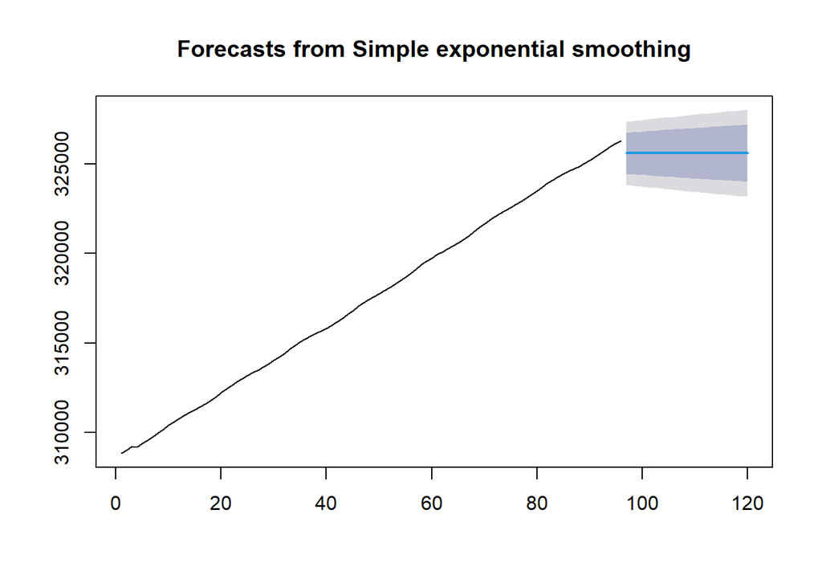

```r
#Cara 1 (fungsi ses)
ses.1 <- ses(train.ts, h = 24, alpha = 0.2)
plot(ses.1)
```

```r
ses.1
```

```
##     Point Forecast    Lo 80    Hi 80    Lo 95    Hi 95
##  97         325593 324449.3 326736.8 323843.8 327342.3
##  98         325593 324426.6 326759.5 323809.1 327376.9
##  99         325593 324404.4 326781.7 323775.1 327410.9
## 100         325593 324382.6 326803.5 323741.8 327444.3
## 101         325593 324361.1 326824.9 323709.0 327477.1
## 102         325593 324340.1 326846.0 323676.8 327509.3
## 103         325593 324319.4 326866.7 323645.1 327540.9
## 104         325593 324299.0 326887.1 323614.0 327572.1
## 105         325593 324278.9 326907.1 323583.3 327602.8
## 106         325593 324259.2 326926.9 323553.1 327633.0
## 107         325593 324239.7 326946.4 323523.3 327662.8
## 108         325593 324220.5 326965.6 323493.9 327692.2
## 109         325593 324201.6 326984.5 323465.0 327721.1
## 110         325593 324182.9 327003.2 323436.4 327749.7
## 111         325593 324164.4 327021.6 323408.2 327777.9
## 112         325593 324146.2 327039.8 323380.4 327805.7
## 113         325593 324128.3 327057.8 323352.9 327833.2
## 114         325593 324110.5 327075.6 323325.7 327860.3
## 115         325593 324093.0 327093.1 323298.9 327887.2
## 116         325593 324075.6 327110.4 323272.4 327913.7
## 117         325593 324058.5 327127.6 323246.1 327939.9
## 118         325593 324041.5 327144.5 323220.2 327965.9
## 119         325593 324024.8 327161.3 323194.6 327991.5
## 120         325593 324008.2 327177.9 323169.2 328016.9
```

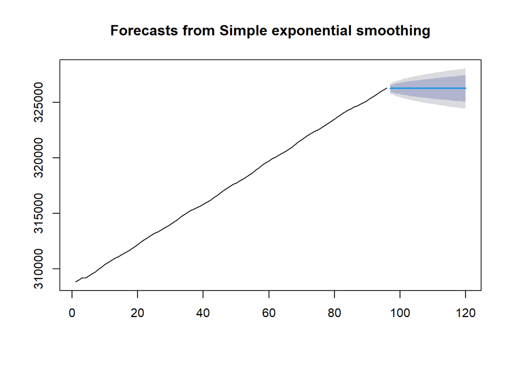

```r
ses.2<- ses(train.ts, h = 24, alpha = 0.8)
plot(ses.2)
```

```r
ses.2
```

```
##     Point Forecast    Lo 80    Hi 80    Lo 95    Hi 95
##  97       326260.2 325961.1 326559.2 325802.8 326717.5
##  98       326260.2 325877.2 326643.1 325674.5 326845.9
##  99       326260.2 325808.6 326711.7 325569.6 326950.7
## 100       326260.2 325749.2 326771.2 325478.7 327041.7
## 101       326260.2 325695.9 326824.4 325397.2 327123.1
## 102       326260.2 325647.3 326873.0 325322.9 327197.4
## 103       326260.2 325602.3 326918.1 325254.0 327266.3
## 104       326260.2 325560.1 326960.2 325189.5 327330.8
## 105       326260.2 325520.4 327000.0 325128.8 327391.6
## 106       326260.2 325482.7 327037.7 325071.1 327449.3
## 107       326260.2 325446.7 327073.6 325016.1 327504.3
## 108       326260.2 325412.2 327108.1 324963.4 327557.0
## 109       326260.2 325379.1 327141.2 324912.7 327607.6
## 110       326260.2 325347.2 327173.1 324864.0 327656.4
## 111       326260.2 325316.4 327203.9 324816.8 327703.5
## 112       326260.2 325286.6 327233.8 324771.2 327749.2
## 113       326260.2 325257.6 327262.7 324726.9 327793.5
## 114       326260.2 325229.4 327290.9 324683.8 327836.5
## 115       326260.2 325202.0 327318.3 324641.9 327878.4
## 116       326260.2 325175.3 327345.0 324601.1 327919.3
## 117       326260.2 325149.3 327371.1 324561.2 327959.1
## 118       326260.2 325123.8 327396.5 324522.3 327998.1
## 119       326260.2 325098.9 327421.4 324484.2 328036.2
## 120       326260.2 325074.5 327445.8 324446.9 328073.5
```

Untuk mendapatkan gambar hasil pemulusan pada data training dengan fungsi `ses()` , perlu digunakan fungsi `autoplot()` dan `autolayer()` dari *library packages* `ggplot2` .

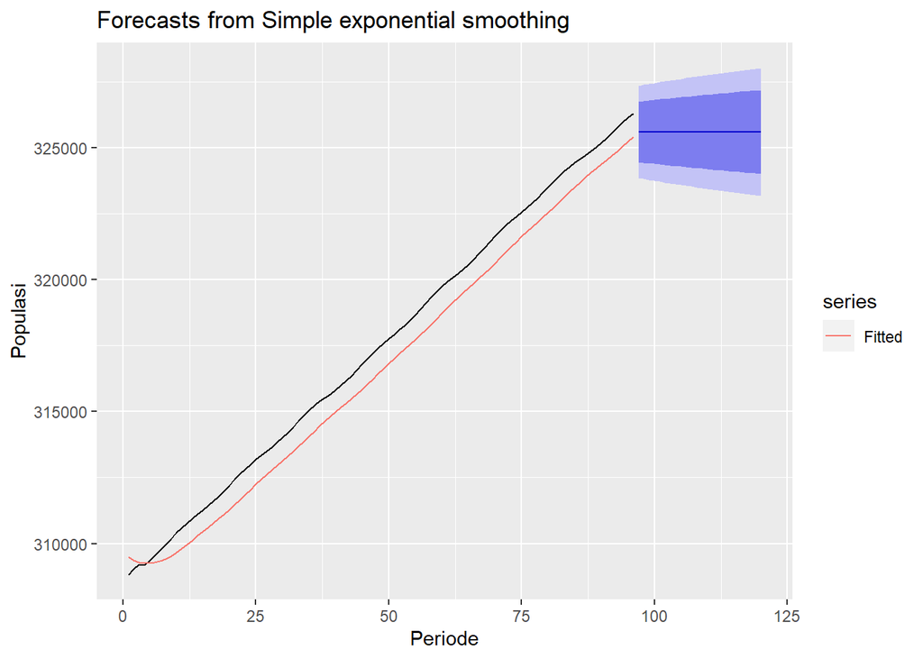

```r
autoplot(ses.1) +
  autolayer(fitted(ses.1), series="Fitted") +
  ylab("Populasi") + xlab("Periode")
```

Selanjutnya akan digunakan fungsi `HoltWinters()` dengan nilai inisialisasi parameter dan panjang periode peramalan yang sama dengan fungsi `ses()` .

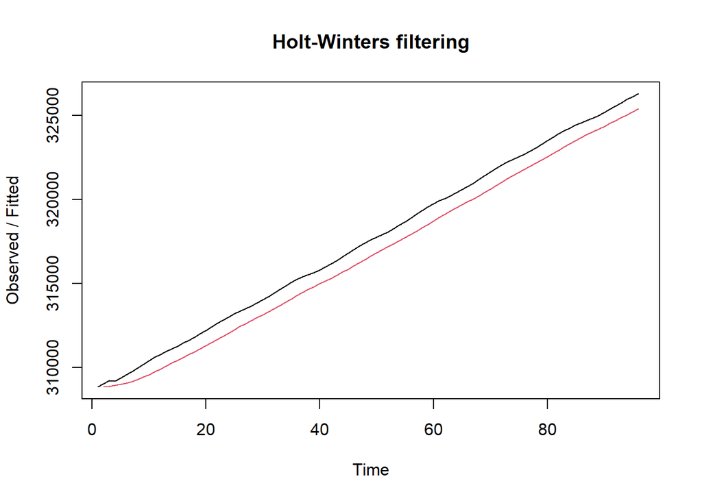

```r
#Cara 2 (fungsi Holtwinter)
ses1<- HoltWinters(train.ts, gamma = FALSE, beta = FALSE, alpha = 0.2)
plot(ses1)
```

```r
#ramalan
ramalan1<- forecast(ses1, h=24)
ramalan1
```

```
##     Point Forecast    Lo 80    Hi 80    Lo 95    Hi 95
##  97         325593 325399.4 325786.7 325296.9 325889.2
##  98         325593 325395.6 325790.5 325291.0 325895.0
##  99         325593 325391.8 325794.3 325285.3 325900.8
## 100         325593 325388.1 325798.0 325279.6 325906.4
## 101         325593 325384.5 325801.6 325274.1 325912.0
## 102         325593 325380.9 325805.2 325268.6 325917.4
## 103         325593 325377.4 325808.7 325263.3 325922.8
## 104         325593 325374.0 325812.1 325258.0 325928.1
## 105         325593 325370.6 325815.5 325252.8 325933.3
## 106         325593 325367.2 325818.9 325247.7 325938.4
## 107         325593 325363.9 325822.2 325242.6 325943.4
## 108         325593 325360.7 325825.4 325237.7 325948.4
## 109         325593 325357.5 325828.6 325232.8 325953.3
## 110         325593 325354.3 325831.8 325227.9 325958.1
## 111         325593 325351.2 325834.9 325223.2 325962.9
## 112         325593 325348.1 325838.0 325218.4 325967.6
## 113         325593 325345.1 325841.0 325213.8 325972.3
## 114         325593 325342.1 325844.0 325209.2 325976.9
## 115         325593 325339.1 325847.0 325204.6 325981.4
## 116         325593 325336.1 325849.9 325200.2 325985.9
## 117         325593 325333.2 325852.8 325195.7 325990.4
## 118         325593 325330.4 325855.7 325191.3 325994.7
## 119         325593 325327.5 325858.5 325187.0 325999.1
## 120         325593 325324.7 325861.3 325182.7 326003.4
```

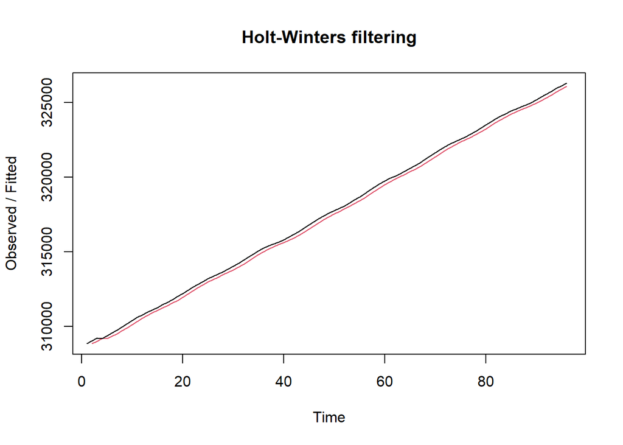

```r
ses2<- HoltWinters(train.ts, gamma = FALSE, beta = FALSE, alpha = 0.8)
plot(ses2)
```

```r
#ramalan
ramalan2<- forecast(ses2, h=24)
ramalan2
```

```
##     Point Forecast    Lo 80    Hi 80    Lo 95    Hi 95
##  97       326260.2 326213.4 326307.0 326188.6 326331.7
##  98       326260.2 326200.2 326320.1 326168.5 326351.8
##  99       326260.2 326189.5 326330.8 326152.1 326368.2
## 100       326260.2 326180.2 326340.1 326137.9 326382.4
## 101       326260.2 326171.9 326348.4 326125.1 326395.2
## 102       326260.2 326164.3 326356.1 326113.5 326406.8
## 103       326260.2 326157.2 326363.1 326102.7 326417.6
## 104       326260.2 326150.6 326369.7 326092.6 326427.7
## 105       326260.2 326144.4 326375.9 326083.1 326437.2
## 106       326260.2 326138.5 326381.8 326074.1 326446.2
## 107       326260.2 326132.9 326387.4 326065.5 326454.8
## 108       326260.2 326127.5 326392.8 326057.3 326463.1
## 109       326260.2 326122.3 326398.0 326049.3 326471.0
## 110       326260.2 326117.3 326403.0 326041.7 326478.6
## 111       326260.2 326112.5 326407.8 326034.3 326486.0
## 112       326260.2 326107.8 326412.5 326027.2 326493.1
## 113       326260.2 326103.3 326417.0 326020.3 326500.1
## 114       326260.2 326098.9 326421.4 326013.5 326506.8
## 115       326260.2 326094.6 326425.7 326007.0 326513.4
## 116       326260.2 326090.4 326429.9 326000.6 326519.8
## 117       326260.2 326086.3 326434.0 325994.3 326526.0
## 118       326260.2 326082.4 326438.0 325988.2 326532.1
## 119       326260.2 326078.5 326441.9 325982.3 326538.1
## 120       326260.2 326074.6 326445.7 325976.4 326543.9
```

Fungsi `HoltWinters` memiliki argumen yang sama dengan fungsi `ses()` . Argumen-argumen kedua fungsi dapat dilihat lebih lanjut dengan `?ses()` atau `?HoltWinters` .

Nilai parameter $\alpha$ dari kedua fungsi dapat dioptimalkan menyesuaikan dari *error*-nya paling minimumnya. Caranya adalah dengan membuat parameter $\alpha =$ `NULL` .

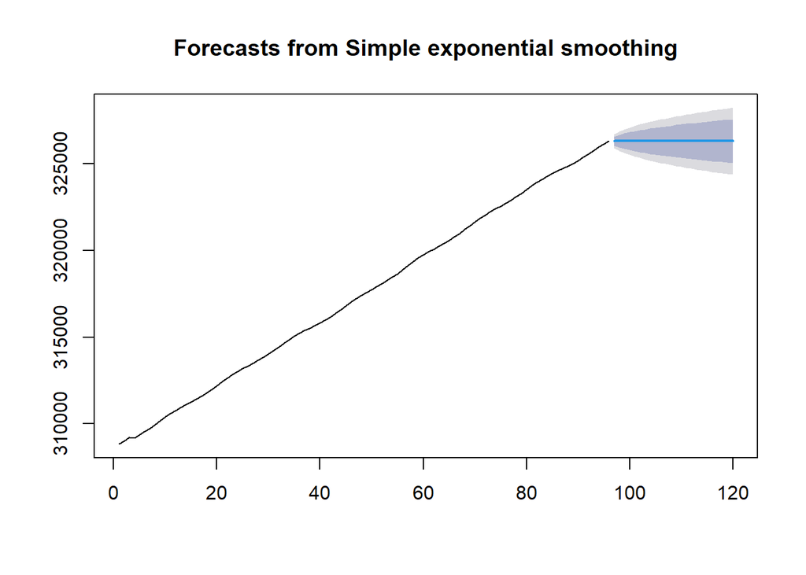

```r
#SES
ses.opt <- ses(train.ts, h = 24, alpha = NULL)
plot(ses.opt)
```

```r
ses.opt
```

```
##     Point Forecast    Lo 80    Hi 80    Lo 95    Hi 95
##  97         326301 326042.7 326559.2 325906.0 326695.9
##  98         326301 325935.8 326666.2 325742.5 326859.5
##  99         326301 325853.7 326748.3 325616.9 326985.0
## 100         326301 325784.5 326817.4 325511.1 327090.8
## 101         326301 325723.6 326878.4 325417.9 327184.1
## 102         326301 325668.5 326933.5 325333.6 327268.4
## 103         326301 325617.8 326984.2 325256.1 327345.9
## 104         326301 325570.6 327031.4 325184.0 327418.0
## 105         326301 325526.3 327075.7 325116.2 327485.8
## 106         326301 325484.4 327117.6 325052.1 327549.8
## 107         326301 325444.5 327157.4 324991.2 327610.8
## 108         326301 325406.5 327195.5 324932.9 327669.0
## 109         326301 325369.9 327232.0 324877.1 327724.9
## 110         326301 325334.8 327267.2 324823.3 327778.6
## 111         326301 325300.9 327301.1 324771.5 327830.5
## 112         326301 325268.1 327333.9 324721.3 327880.7
## 113         326301 325236.3 327365.7 324672.7 327929.3
## 114         326301 325205.4 327396.5 324625.5 327976.5
## 115         326301 325175.4 327426.6 324579.6 328022.4
## 116         326301 325146.2 327455.8 324534.8 328067.1
## 117         326301 325117.6 327484.3 324491.2 328110.7
## 118         326301 325089.8 327512.2 324448.6 328153.3
## 119         326301 325062.6 327539.4 324407.0 328195.0
## 120         326301 325035.9 327566.0 324366.3 328235.7
```

```r
#Lamda Optimum Holt Winter
sesopt<- HoltWinters(train.ts, gamma = FALSE, beta = FALSE,alpha = NULL)
sesopt
```

```
## Holt-Winters exponential smoothing without trend and without seasonal component.
##
## Call:
## HoltWinters(x = train.ts, alpha = NULL, beta = FALSE, gamma = FALSE)
##
## Smoothing parameters:
##  alpha: 0.9999477
##  beta : FALSE
##  gamma: FALSE
##
## Coefficients:
##     [,1]
## a 326301
```

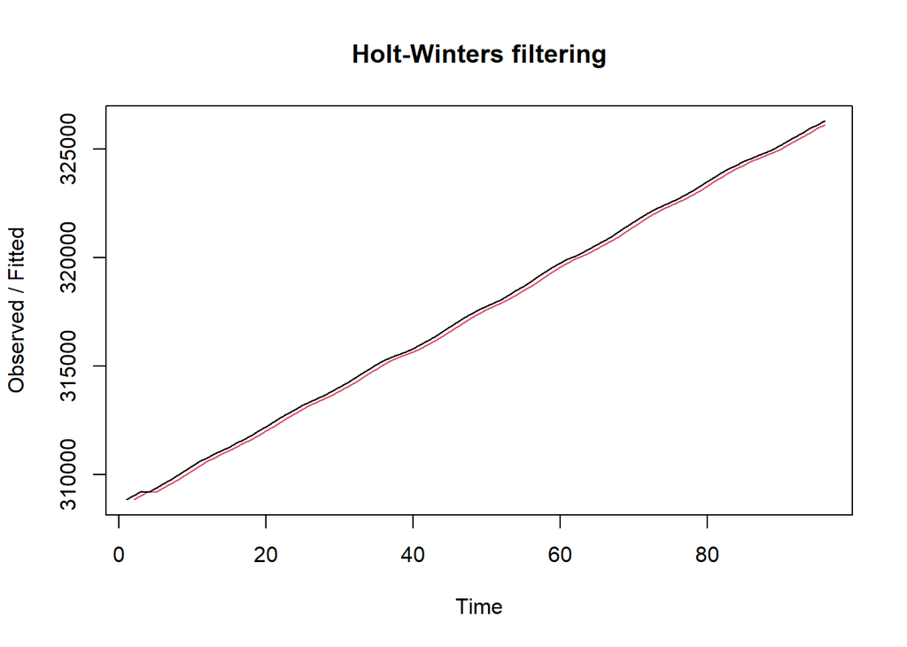

```r
plot(sesopt)
```

```r
#ramalan
ramalanopt<- forecast(sesopt, h=24)
ramalanopt
```

```
##     Point Forecast    Lo 80    Hi 80    Lo 95    Hi 95
##  97         326301 326259.6 326342.4 326237.7 326364.3
##  98         326301 326242.4 326359.6 326211.4 326390.6
##  99         326301 326229.3 326372.7 326191.3 326410.7
## 100         326301 326218.2 326383.8 326174.3 326427.7
## 101         326301 326208.4 326393.6 326159.4 326442.6
## 102         326301 326199.5 326402.4 326145.8 326456.1
## 103         326301 326191.4 326410.6 326133.4 326468.6
## 104         326301 326183.9 326418.1 326121.8 326480.1
## 105         326301 326176.7 326425.2 326111.0 326491.0
## 106         326301 326170.0 326432.0 326100.7 326501.3
## 107         326301 326163.6 326438.3 326090.9 326511.1
## 108         326301 326157.5 326444.5 326081.6 326520.4
## 109         326301 326151.7 326450.3 326072.6 326529.4
## 110         326301 326146.0 326456.0 326064.0 326538.0
## 111         326301 326140.6 326461.4 326055.7 326546.3
## 112         326301 326135.3 326466.6 326047.6 326554.3
## 113         326301 326130.2 326471.7 326039.8 326562.1
## 114         326301 326125.3 326476.7 326032.3 326569.7
## 115         326301 326120.5 326481.5 326024.9 326577.1
## 116         326301 326115.8 326486.2 326017.7 326584.2
## 117         326301 326111.2 326490.8 326010.7 326591.2
## 118         326301 326106.7 326495.2 326003.9 326598.1
## 119         326301 326102.4 326499.6 325997.2 326604.7
## 120         326301 326098.1 326503.9 325990.7 326611.3
```

Selanjutnya, dilakukan perhitungan akurasi pada data training dan data test.

#### Akurasi Data Latih

```r
#Keakuratan Metode
#Pada data training
SSE1<-ses1$SSE
MSE1<-ses1$SSE/length(train.ts)
RMSE1<-sqrt(MSE1)

akurasi1 <- matrix(c(SSE1,MSE1,RMSE1))
row.names(akurasi1)<- c("SSE", "MSE", "RMSE")
colnames(akurasi1) <- c("Akurasi lamda=0.2")
akurasi1
```

```
##      Akurasi lamda=0.2
## SSE       7.606677e+07
## MSE       7.923622e+05
## RMSE      8.901473e+02
```

```r
SSE2<-ses2$SSE
MSE2<-ses2$SSE/length(train.ts)
RMSE2<-sqrt(MSE2)

akurasi2 <- matrix(c(SSE2,MSE2,RMSE2))
row.names(akurasi2)<- c("SSE", "MSE", "RMSE")
colnames(akurasi2) <- c("Akurasi lamda=0.8")
akurasi2
```

```
##      Akurasi lamda=0.8
## SSE       5120472.9689
## MSE         53338.2601
## RMSE          230.9508
```

```r
#Cara Manual
fitted1<-ramalan1$fitted
sisaan1<-ramalan1$residuals
head(sisaan1)
```

```
## Time Series:
## Start = 1
## End = 6
## Frequency = 1
## [1]       NA 194.0000 340.2000 251.1600 378.9280 483.1424
```

```r
resid1<-training$value-ramalan1$fitted
head(resid1)
```

```
## Time Series:
## Start = 1
## End = 6
## Frequency = 1
## [1]       NA 194.0000 340.2000 251.1600 378.9280 483.1424
```

Menghitung MAPE dengan cara manual

```r
SSE.1=sum(sisaan1[2:length(train.ts)]^2)
SSE.1
```

```
## [1] 76066774
```

```r
MSE.1 = SSE.1/length(train.ts)
MSE.1
```

```
## [1] 792362.2
```

```r
MAPE.1 = sum(abs(sisaan1[2:length(train.ts)]/train.ts[2:length(train.ts)])*
               100)/length(train.ts)
MAPE.1
```

```
## [1] 0.2745413
```

```r
akurasi.1 <- matrix(c(SSE.1,MSE.1,MAPE.1))
row.names(akurasi.1)<- c("SSE", "MSE", "MAPE")
colnames(akurasi.1) <- c("Akurasi lamda=0.2")
akurasi.1
```

```
##      Akurasi lamda=0.2
## SSE       7.606677e+07
## MSE       7.923622e+05
## MAPE      2.745413e-01
```

```r
fitted2<-ramalan2$fitted
sisaan2<-ramalan2$residuals
head(sisaan2)
```

```
## Time Series:
## Start = 1
## End = 6
## Frequency = 1
## [1]       NA 194.0000 223.8000  23.7600 182.7520 216.5504
```

```r
resid2<-training$value-ramalan2$fitted
head(resid2)
```

```
## Time Series:
## Start = 1
## End = 6
## Frequency = 1
## [1]       NA 194.0000 223.8000  23.7600 182.7520 216.5504
```

```r
SSE.2=sum(sisaan2[2:length(train.ts)]^2)
SSE.2
```

```
## [1] 5120473
```

```r
MSE.2 = SSE.2/length(train.ts)
MSE.2
```

```
## [1] 53338.26
```

```r
MAPE.2 = sum(abs(sisaan2[2:length(train.ts)]/train.ts[2:length(train.ts)])*
               100)/length(train.ts)
MAPE.2
```

```
## [1] 0.07144538
```

```r
akurasi.2 <- matrix(c(SSE.2,MSE.2,MAPE.2))
row.names(akurasi.2)<- c("SSE", "MSE", "MAPE")
colnames(akurasi.2) <- c("Akurasi lamda=0.8")
akurasi.2
```

```
##      Akurasi lamda=0.8
## SSE       5.120473e+06
## MSE       5.333826e+04
## MAPE      7.144538e-02
```

Berdasarkan nilai SSE, MSE, RMSE, dan MAPE di antara kedua parameter, nilai parameter $\lambda=0.8$ menghasilkan akurasi yang lebih baik dibanding $\lambda=0.2$ . Dari nilai MAPE yang dihasilkan, terlihat bahwa peramalan sangat baik karena kedua MAPE yang dihasilkan < 10%.

#### Akurasi Data Test

Akurasi data test dapat dihitung dengan cara yang hampir sama dengan perhitungan akurasi data training.

```r
pengurangan1<-ramalan1$mean-testing$value
SSEtesting1<-sum(pengurangan1^2)
MSEtesting1<-SSEtesting1/length(testing)

pengurangan2<-ramalan2$mean-testing$value
SSEtesting2<-sum(pengurangan2^2)
MSEtesting2<-SSEtesting2/length(testing)

penguranganopt<-ramalanopt$mean-testing$value
SSEtestingopt<-sum(penguranganopt^2)
MSEtestingopt<-SSEtestingopt/length(testing)

akurasitesting1 <- matrix(c(SSEtesting1,SSEtesting2,SSEtestingopt))
row.names(akurasitesting1)<- c("SSE1", "SSE2", "SSEopt")
akurasitesting1
```

```
##             [,1]
## SSE1   214984224
## SSE2   137368406
## SSEopt 133312150
```

```r
akurasitesting2 <- matrix(c(MSEtesting1,MSEtesting2,MSEtestingopt))
row.names(akurasitesting2)<- c("MSE1", "MSE2", "MSEopt")
akurasitesting2
```

```
##             [,1]
## MSE1   107492112
## MSE2    68684203
## MSEopt  66656075
```

## Double Exponential Smoothing (DES)

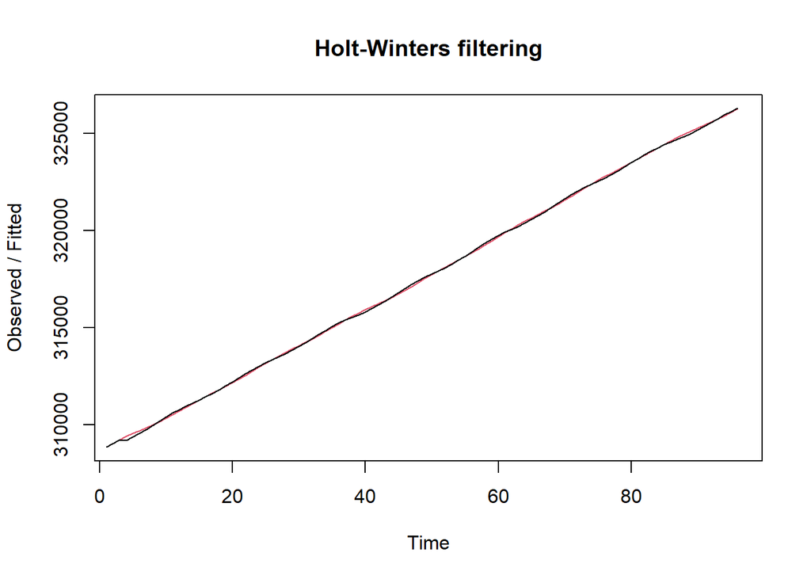

```r
#Lamda=0.2 dan gamma=0.2
des.1<- HoltWinters(train.ts, gamma = FALSE, beta = 0.2, alpha = 0.2)
plot(des.1)
```

```r
#ramalan
ramalandes1<- forecast(des.1, h=24)
ramalandes1
```

```
##     Point Forecast    Lo 80    Hi 80    Lo 95    Hi 95
##  97       326451.2 326365.2 326537.3 326319.7 326582.8
##  98       326622.2 326533.7 326710.7 326486.9 326757.5
##  99       326793.2 326701.5 326884.9 326653.0 326933.4
## 100       326964.2 326868.4 327059.9 326817.7 327110.6
## 101       327135.1 327034.5 327235.7 326981.2 327289.0
## 102       327306.1 327199.8 327412.4 327143.5 327468.7
## 103       327477.1 327364.2 327589.9 327304.4 327649.7
## 104       327648.0 327527.9 327768.2 327464.2 327831.8
## 105       327819.0 327690.8 327947.3 327622.9 328015.1
## 106       327990.0 327853.0 328127.0 327780.5 328199.5
## 107       328161.0 328014.6 328307.3 327937.1 328384.8
## 108       328331.9 328175.5 328488.3 328092.7 328571.1
## 109       328502.9 328335.9 328669.9 328247.5 328758.3
## 110       328673.9 328495.8 328852.0 328401.5 328946.2
## 111       328844.8 328655.1 329034.6 328554.7 329135.0
## 112       329015.8 328814.0 329217.6 328707.2 329324.5
## 113       329186.8 328972.4 329401.1 328859.0 329514.6
## 114       329357.8 329130.4 329585.1 329010.1 329705.4
## 115       329528.7 329288.0 329769.4 329160.6 329896.9
## 116       329699.7 329445.2 329954.2 329310.5 330088.9
## 117       329870.7 329602.0 330139.3 329459.8 330281.5
## 118       330041.6 329758.5 330324.8 329608.6 330474.7
## 119       330212.6 329914.6 330510.6 329756.9 330668.4
## 120       330383.6 330070.4 330696.8 329904.6 330862.6
```

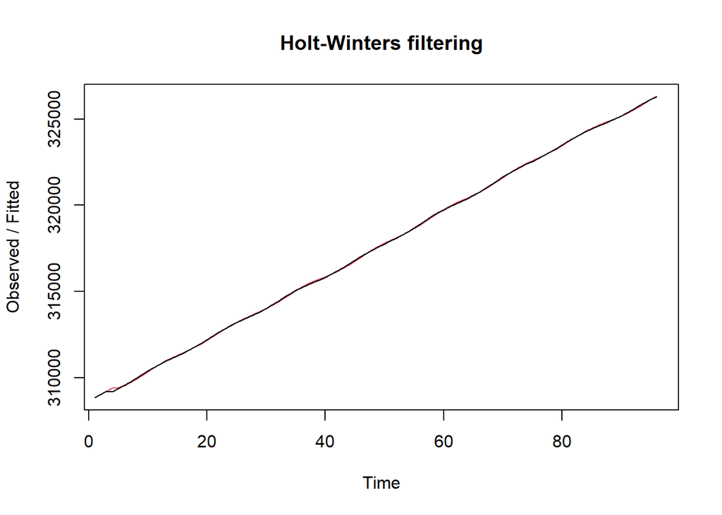

```r
#Lamda=0.6 dan gamma=0.3
des.2<- HoltWinters(train.ts, gamma = FALSE, beta = 0.2, alpha = 0.7)
plot(des.2)
```

```r
#ramalan
ramalandes2<- forecast(des.2, h=24)
ramalandes2
```

```
##     Point Forecast    Lo 80    Hi 80    Lo 95    Hi 95
##  97       326486.2 326432.1 326540.4 326403.5 326569.0
##  98       326665.2 326594.5 326735.8 326557.0 326773.3
##  99       326844.1 326755.7 326932.4 326708.9 326979.2
## 100       327023.0 326915.8 327130.1 326859.1 327186.9
## 101       327201.9 327074.8 327328.9 327007.6 327396.2
## 102       327380.8 327232.9 327528.7 327154.6 327607.0
## 103       327559.7 327389.9 327729.5 327300.0 327819.4
## 104       327738.6 327546.0 327931.2 327444.0 328033.2
## 105       327917.5 327701.2 328133.9 327586.6 328248.4
## 106       328096.4 327855.5 328337.4 327727.9 328464.9
## 107       328275.3 328008.9 328541.7 327867.9 328682.8
## 108       328454.2 328161.5 328746.9 328006.6 328901.9
## 109       328633.1 328313.3 328953.0 328144.0 329122.3
## 110       328812.0 328464.4 329159.7 328280.3 329343.8
## 111       328991.0 328614.6 329367.3 328415.4 329566.5
## 112       329169.9 328764.2 329575.6 328549.4 329790.3
## 113       329348.8 328913.0 329784.6 328682.3 330015.3
## 114       329527.7 329061.1 329994.3 328814.1 330241.3
## 115       329706.6 329208.5 330204.7 328944.8 330468.3
## 116       329885.5 329355.2 330415.7 329074.5 330696.4
## 117       330064.4 329501.3 330627.5 329203.2 330925.6
## 118       330243.3 329646.7 330839.9 329330.9 331155.7
## 119       330422.2 329791.5 331052.9 329457.7 331386.7
## 120       330601.1 329935.7 331266.5 329583.5 331618.8
```

Selanjutnya membandingkan plot data training dan data test.

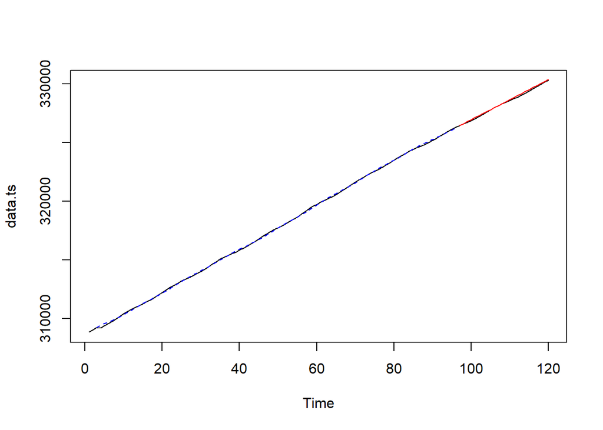

```r
#Mengevaluasi prediksi secara visual
plot(data.ts)
lines(des.1$fitted[,1], lty=2, col="blue")
lines(ramalandes1$mean, col="red")
```

Untuk mendapatkan nilai parameter optimum dari DES, argumen `alpha` dan `beta` dapat dibuat `NULL` seperti berikut.

```r
#Lamda dan gamma optimum
des.opt<- HoltWinters(train.ts, gamma = FALSE)
des.opt
```

```
## Holt-Winters exponential smoothing with trend and without seasonal component.
##
## Call:
## HoltWinters(x = train.ts, gamma = FALSE)
##
## Smoothing parameters:
##  alpha: 1
##  beta : 0.02503102
##  gamma: FALSE
##
## Coefficients:
##         [,1]
## a 326301.000
## b    184.374
```

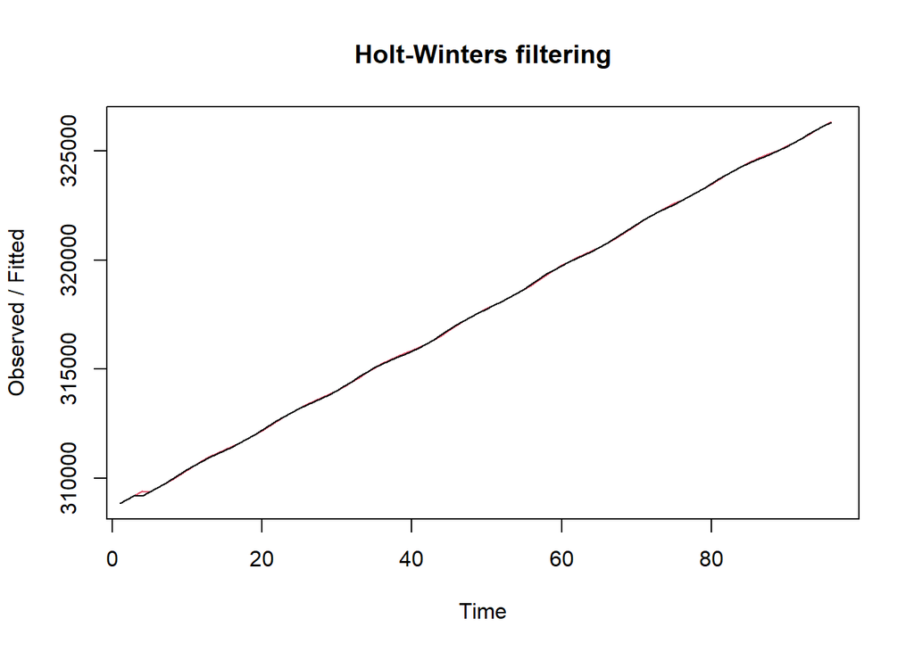

```r
plot(des.opt)
```

```r
#ramalan
ramalandesopt<- forecast(des.opt, h=24)
ramalandesopt
```

```
##     Point Forecast    Lo 80    Hi 80    Lo 95    Hi 95
##  97       326485.4 326443.1 326527.7 326420.7 326550.1
##  98       326669.7 326609.2 326730.3 326577.1 326762.4
##  99       326854.1 326779.0 326929.2 326739.3 326969.0
## 100       327038.5 326950.7 327126.3 326904.2 327172.8
## 101       327222.9 327123.5 327322.2 327070.9 327374.8
## 102       327407.2 327297.1 327517.4 327238.7 327575.7
## 103       327591.6 327471.2 327712.1 327407.4 327775.8
## 104       327776.0 327645.7 327906.3 327576.7 327975.3
## 105       327960.4 327820.5 328100.2 327746.5 328174.2
## 106       328144.7 327995.6 328293.9 327916.7 328372.8
## 107       328329.1 328170.9 328487.3 328087.1 328571.1
## 108       328513.5 328346.3 328680.7 328257.8 328769.1
## 109       328697.9 328521.9 328873.8 328428.7 328967.0
## 110       328882.2 328697.5 329066.9 328599.8 329164.7
## 111       329066.6 328873.3 329259.9 328770.9 329362.3
## 112       329251.0 329049.1 329452.9 328942.2 329559.7
## 113       329435.4 329225.0 329645.8 329113.6 329757.1
## 114       329619.7 329400.9 329838.6 329285.0 329954.5
## 115       329804.1 329576.8 330031.4 329456.5 330151.7
## 116       329988.5 329752.8 330224.2 329628.0 330349.0
## 117       330172.9 329928.7 330417.0 329799.5 330546.2
## 118       330357.2 330104.7 330609.7 329971.1 330743.4
## 119       330541.6 330280.7 330802.5 330142.6 330940.6
## 120       330726.0 330456.7 330995.2 330314.2 331137.8
```

Selanjutnya akan dilakukan perhitungan akurasi pada data training maupun data test dengan ukuran akurasi SSE, MSE dan MAPE.

#### Akurasi Data Training

```r
#Akurasi Data Training
ssedes.train1<-des.1$SSE
msedes.train1<-ssedes.train1/length(train.ts)
sisaandes1<-ramalandes1$residuals
head(sisaandes1)
```

```
## Time Series:
## Start = 1
## End = 6
## Frequency = 1
## [1]        NA        NA   -9.0000 -221.8400 -184.2384 -144.7876
```

```r
mapedes.train1 <- sum(abs(sisaandes1[3:length(train.ts)]/train.ts[3:length(train.ts)])
                      *100)/length(train.ts)

akurasides.1 <- matrix(c(ssedes.train1,msedes.train1,mapedes.train1))
row.names(akurasides.1)<- c("SSE", "MSE", "MAPE")
colnames(akurasides.1) <- c("Akurasi lamda=0.2 dan gamma=0.2")
akurasides.1
```

```
##      Akurasi lamda=0.2 dan gamma=0.2
## SSE                     4.225474e+05
## MSE                     4.401536e+03
## MAPE                    1.690031e-02
```

```r
ssedes.train2<-des.2$SSE
msedes.train2<-ssedes.train2/length(train.ts)
sisaandes2<-ramalandes2$residuals
head(sisaandes2)
```

```
## Time Series:
## Start = 1
## End = 6
## Frequency = 1
## [1]          NA          NA   -9.000000 -216.440000  -49.370400    9.662336
```

```r
mapedes.train2 <- sum(abs(sisaandes2[3:length(train.ts)]/train.ts[3:length(train.ts)])
                      *100)/length(train.ts)

akurasides.2 <- matrix(c(ssedes.train2,msedes.train2,mapedes.train2))
row.names(akurasides.2)<- c("SSE", "MSE", "MAPE")
colnames(akurasides.2) <- c("Akurasi lamda=0.7 dan gamma=0.2")
akurasides.2
```

```
##      Akurasi lamda=0.7 dan gamma=0.2
## SSE                     1.660384e+05
## MSE                     1.729566e+03
## MAPE                    1.014310e-02
```

Hasil akurasi dari data latih didapatkan skenario 2 dengan lamda=0.7 dan gamma=0.2 memiliki hasil yang lebih baik. Namun untuk kedua skenario dapat dikategorikan peramalan sangat baik berdasarkan nilai MAPE-nya.

#### Akurasi Data Uji

```r
#Akurasi Data Testing
selisihdes1<-ramalandes1$mean-testing$value
selisihdes1
```

```
## Time Series:
## Start = 97
## End = 120
## Frequency = 1
##  [1]  -2.763499  21.208464  56.180428  76.152391  86.124355  87.096318
##  [7]  73.068282  48.040245  25.012209  -1.015828  -3.043864  12.928099
## [13]  34.900063  62.872026 102.843990 125.815953 139.787917 143.759880
## [19] 133.731844 108.703807  84.675770  59.647734  57.619697  74.591661
```

```r
SSEtestingdes1<-sum(selisihdes1^2)
MSEtestingdes1<-SSEtestingdes1/length(testing$value)
MAPEtestingdes1<-sum(abs(selisihdes1/testing$value)*100)/length(testing$value)

selisihdes2<-ramalandes2$mean-testing$value
selisihdes2
```

```
## Time Series:
## Start = 97
## End = 120
## Frequency = 1
##  [1]  32.24839  64.15572 107.06306 134.97039 152.87772 161.78506 155.69239
##  [8] 138.59973 123.50706 105.41439 111.32173 135.22906 165.13640 201.04373
## [15] 248.95106 279.85840 301.76573 313.67307 311.58040 294.48773 278.39507
## [22] 261.30240 267.20973 292.11707
```

```r
SSEtestingdes2<-sum(selisihdes2^2)
MSEtestingdes2<-SSEtestingdes2/length(testing$rate)
```

```r
MAPEtestingdes2<-sum(abs(selisihdes2/testing$value)*100)/length(testing$value)

selisihdesopt<-ramalandesopt$mean-testing$value
selisihdesopt
```

```
## Time Series:
## Start = 97
## End = 120
## Frequency = 1
##  [1]  31.37403  68.74806 117.12210 150.49613 173.87016 188.24419 187.61822
##  [8] 175.99225 166.36629 153.74032 165.11435 194.48838 229.86241 271.23644
## [15] 324.61048 360.98451 388.35854 405.73257 409.10660 397.48063 386.85467
## [22] 375.22870 386.60273 416.97676
```

```r
SSEtestingdesopt<-sum(selisihdesopt^2)
MSEtestingdesopt<-SSEtestingdesopt/length(testing$value)
MAPEtestingdesopt<-sum(abs(selisihdesopt/testing$value)*100)/length(testing$value)

akurasitestingdes <-
  matrix(c(SSEtestingdes1,MSEtestingdes1,MAPEtestingdes1,SSEtestingdes2,MSEtestingdes2,
           MAPEtestingdes2,SSEtestingdesopt,MSEtestingdesopt,MAPEtestingdesopt),
         nrow=3,ncol=3)
row.names(akurasitestingdes)<- c("SSE", "MSE", "MAPE")
colnames(akurasitestingdes) <- c("des ske1","des ske2","des opt")
akurasitestingdes
```

```
##          des ske1     des ske2      des opt
## SSE  1.539634e+05 1.068638e+06 1.906993e+06
## MSE  6.415143e+03          Inf 7.945803e+04
## MAPE 2.055763e-02 5.878066e-02 7.762010e-02
```

#### Perbandingan SES dan DES

```r
MSEfull <-
  matrix(c(MSEtesting1,MSEtesting2,MSEtestingopt,MSEtestingdes1,MSEtestingdes2,
           MSEtestingdesopt),nrow=3,ncol=2)
row.names(MSEfull)<- c("ske 1", "ske 2", "ske opt")
colnames(MSEfull) <- c("ses","des")
MSEfull
```

```
##               ses       des
## ske 1   107492112  6415.143
## ske 2    68684203       Inf
## ske opt  66656075 79458.026
```

### Kesimpulan

Dari kedua uji exponential smoothing yang dilakukan, terlihat bahwa metode double exponential smoothing lebih baik digunakan pada data ini yang berpola tren dibandingkan menggunakan metode single exponential smoothing. Berdasarkan hasil yang didapatkan dapat dilihat bahwa metode DES lebih baik digunakan dibandingkan dengan SES pada data yang berpola trend ```